# Orange Juice Prediction and Analysis

Ian Donovan

6/2/2020

```r
library(ISLR)
library(e1071)
library(glmnet)
library(pls)
attach(OJ)
```

# Problem 1.

**1. Create a training set containing a random sample of 800 observations, and a test set containing the remaining observations.**

```r
set.seed(1)
train = sample(1:nrow(OJ), 800)
test = -train
```

## SVMs

**2. Fit a support vector classiﬁer to the training data using cost = 0.01, with Purchase as the response and the other variables as predictors. Use the summary() function to produce summary statistics, and describe the results obtained.**

```r
svmfit=svm(Purchase~., data=OJ[train,], kernel="linear", cost=0.01, scale=FALSE)
summary(svmfit)
```

```
##
## Call:
## svm(formula = Purchase ~ ., data = OJ[train, ], kernel = "linear",
##     cost = 0.01, scale = FALSE)
##
##
## Parameters:
##    SVM-Type:  C-classification
##  SVM-Kernel:  linear
##        cost:  0.01
##
## Number of Support Vectors:  615
##
##  ( 309 306 )
##
##
## Number of Classes:  2
##
## Levels:
##  CH MM
```

**3. What are the training and test error rates?**

```r
train.pred = predict(svmfit, OJ[train,])
table(train.pred, OJ[train,1])
```

```
##
## train.pred  CH  MM
##         CH 420 105
##         MM  65 210
```

```r
1-(420+210)/(420+210+105+65)
```

```
## [1] 0.2125
```

```r
ypred=predict(svmfit, OJ[test,])
table(ypred, OJ[test,1])
```

```
##
## ypred  CH  MM
##    CH 148  43
##    MM  20  59
```

```r
1-(148+59)/(148+59+43+20)
```

```
## [1] 0.2333333
```

**4. Use the tune() function to select an optimal cost. Consider values in the range 0.01 to 10.**

```r
svm.tune = tune(svm, Purchase~., data=OJ[train,], kernel="linear",ranges=list(cost=seq(.01,10.1, by=.5)))
summary(svm.tune)
```

```
##
## Parameter tuning of 'svm':
##
## - sampling method: 10-fold cross validation
##
## - best parameters:
##  cost
##  6.51
##
## - best performance: 0.17
##
## - Detailed performance results:
##     cost   error dispersion
## 1   0.01 0.17375 0.03884174
## 2   0.51 0.17625 0.03197764
## 3   1.01 0.17500 0.03061862
## 4   1.51 0.17500 0.03061862
## 5   2.01 0.17375 0.02972676
## 6   2.51 0.17250 0.03374743
## 7   3.01 0.17250 0.03270236
## 8   3.51 0.17375 0.03408018
## 9   4.01 0.17250 0.03322900
## 10  4.51 0.17250 0.03322900
## 11  5.01 0.17250 0.03322900
## 12  5.51 0.17250 0.03322900
## 13  6.01 0.17125 0.03438447
## 14  6.51 0.17000 0.03593976
## 15  7.01 0.17125 0.03438447
## 16  7.51 0.17125 0.03438447
## 17  8.01 0.17000 0.03593976
## 18  8.51 0.17000 0.03593976
## 19  9.01 0.17125 0.03488573
## 20  9.51 0.17125 0.03488573
## 21 10.01 0.17125 0.03488573
```

```r
svm.tune$best.model
```

```
##
## Call:
## best.tune(method = svm, train.x = Purchase ~ ., data = OJ[train,
##     ], ranges = list(cost = seq(0.01, 10.1, by = 0.5)), kernel = "linear")
##
##
## Parameters:
##    SVM-Type:  C-classification
##  SVM-Kernel:  linear
##        cost:  6.51
##
## Number of Support Vectors:  330
```

```r
best.mod = svm.tune$best.model
```

**5. Compute the training and test error rates using this new value for cost.**

```r
train.pred.best = predict(best.mod, OJ[train, ])
table(train.pred.best, OJ[train,1])
```

```
##
## train.pred.best  CH  MM
##              CH 423  68
##              MM  62 247
```

```r
1-(423+245)/(423+245+70+62)
```

```
## [1] 0.165
```

```r
best.pred = predict(best.mod, OJ[test, ])
table(best.pred, OJ[test,1])
```

```
##
## best.pred  CH  MM
##        CH 156  29
##        MM  12  73
```

```r
1-(146+78)/(146+78+20+26)
```

```
## [1] 0.1703704
```

**6. Repeat part (2)-(5) using a support vector machine with a radial kernel. Use the default value for gamma.**

- Here the best cost value is found to be .51 with the default gamma value

```r
radial.fit = svm(Purchase~., data=OJ[train,], kernel="radial", cost=0.01, scale=FALSE)
summary(radial.fit)
```

```
##
## Call:
## svm(formula = Purchase ~ ., data = OJ[train, ], kernel = "radial",
##     cost = 0.01, scale = FALSE)
##
##
## Parameters:
##    SVM-Type:  C-classification
##  SVM-Kernel:  radial
##        cost:  0.01
##
## Number of Support Vectors:  642
##
##  ( 327 315 )
##
##
## Number of Classes:  2
##
## Levels:
##  CH MM
```

```r
radial.fit$gamma
```

```
## [1] 0.05555556
```

```r
radial.train.pred = predict(radial.fit, OJ[train,])
table(radial.train.pred, OJ[train,1])
```

```
##
## radial.train.pred  CH  MM
##                CH 485 315
##                MM   0   0
```

```r
1-(485)/(485+315)
```

```
## [1] 0.39375
```

```r
radial.test.pred = predict(radial.fit, OJ[test,])
table(radial.test.pred, OJ[test,1])
```

```
##
## radial.test.pred  CH  MM
##               CH 168 102
##               MM   0   0
```

```r
1-(168)/(168+102)
```

```
## [1] 0.3777778
```

```r
radial.tune = tune(svm, Purchase~., data=OJ[train,], kernel="radial",ranges=list(cost=seq(.01,10.1, by=.5)))
summary(radial.tune)
```

```
##
## Parameter tuning of 'svm':
##
## - sampling method: 10-fold cross validation
##
## - best parameters:
##  cost
##  0.51
##
## - best performance: 0.17375
##
## - Detailed performance results:
##     cost   error dispersion
## 1   0.01 0.39375 0.06568284
## 2   0.51 0.17375 0.04767147
## 3   1.01 0.17625 0.03793727
## 4   1.51 0.17750 0.03717451
## 5   2.01 0.17625 0.03606033
## 6   2.51 0.18000 0.04048319
## 7   3.01 0.18500 0.03987829
## 8   3.51 0.18125 0.04379958
## 9   4.01 0.18000 0.04297932
## 10  4.51 0.18125 0.04497299
## 11  5.01 0.18125 0.04299952
## 12  5.51 0.18250 0.04090979
## 13  6.01 0.18125 0.04093101
## 14  6.51 0.18000 0.04297932
## 15  7.01 0.18125 0.04135299
## 16  7.51 0.18125 0.04007372
## 17  8.01 0.18000 0.04005205
## 18  8.51 0.17875 0.04126894
## 19  9.01 0.17875 0.04126894
## 20  9.51 0.18000 0.04216370
## 21 10.01 0.18125 0.04340139
```

```r
radial.tune$best.model
```

```
##
## Call:
## best.tune(method = svm, train.x = Purchase ~ ., data = OJ[train,
##     ], ranges = list(cost = seq(0.01, 10.1, by = 0.5)), kernel = "radial")
##
##
## Parameters:
##    SVM-Type:  C-classification
##  SVM-Kernel:  radial
##        cost:  0.51
##
## Number of Support Vectors:  406
```

```r
best.mod = radial.tune $best.model

tr.pred.best.rad = predict(best.mod, OJ[train,])
table(tr.pred.best.rad, OJ[train,1])
```

```
##
## tr.pred.best.rad  CH  MM
##               CH 438  72
##               MM  47 243
```

```r
1-(438+243)/(438+243+72+42)
```

```
## [1] 0.1433962
```

```r
test.pred.best.rad = predict(best.mod, OJ[test,])
table(test.pred.best.rad, OJ[test,1])
```

```
##
## test.pred.best.rad  CH  MM
##                 CH 150  30
##                 MM  18  72
```

```r
1-(150+72)/(150+72+30+18)
```

```
## [1] 0.1777778
```

**7. Repeat part (2)-(5) using a support vector machine with a polynomial kernel. Set degree = 2.**

```r
poly.fit = svm(Purchase~., data=OJ[train,], kernel="polynomial", degree=2, cost=0.01, scale=FALSE)
summary(poly.fit)
```

```
##
## Call:
## svm(formula = Purchase ~ ., data = OJ[train, ], kernel = "polynomial",
##     degree = 2, cost = 0.01, scale = FALSE)
##
##
## Parameters:
##    SVM-Type:  C-classification
##  SVM-Kernel:  polynomial
##        cost:  0.01
##      degree:  2
##      coef.0:  0
##
## Number of Support Vectors:  333
##
##  ( 166 167 )
##
##
## Number of Classes:  2
##
## Levels:
##  CH MM
```

```r
poly.tr.pred = predict(poly.fit, OJ[train,])
table(poly.tr.pred, OJ[train,1])
```

```
##
## poly.tr.pred  CH  MM
##           CH 423  70
##           MM  62 245
```

```r
1-(423+245)/(423+245+70+62)
```

```
## [1] 0.165
```

```r
poly.test.pred = predict(poly.fit, OJ[test,])
table(poly.test.pred, OJ[test,1])
```

```
##
## poly.test.pred  CH  MM
##             CH 154  29
##             MM  14  73
```

```r
1-(154+73)/(154+73+29+14)
```

```
## [1] 0.1592593
```

```r
poly.tune = tune(svm, Purchase~., data=OJ[train,], kernel="polynomial", degree=2,ranges=list(cost=seq(.01,10.1, by=.5)))
poly.tune$best.model
```

```
##
## Call:
## best.tune(method = svm, train.x = Purchase ~ ., data = OJ[train,
##     ], ranges = list(cost = seq(0.01, 10.1, by = 0.5)), kernel = "polynomial",
##     degree = 2)
##
##
## Parameters:
##    SVM-Type:  C-classification
##  SVM-Kernel:  polynomial
##        cost:  5.51
##      degree:  2
##      coef.0:  0
##
## Number of Support Vectors:  363
```

```r
best.mod = poly.tune$best.model

poly.best.tr = predict(best.mod, OJ[train,])
table(poly.best.tr, OJ[train,1])
```

```
##
## poly.best.tr  CH  MM
##           CH 447  88
##           MM  38 227
```

```r
1-(448+232)/(448+232+83+37)
```

```
## [1] 0.15
```

```r
poly.best.test = predict(best.mod, OJ[test,])
table(poly.best.test, OJ[test,1])
```

```
##
## poly.best.test  CH  MM
##             CH 154  36
##             MM  14  66
```

```r
1-(154+66)/(154+66+37+14)
```

```
## [1] 0.1881919
```

**8. Overall, which approach seems to give the best results on this data?**

# Problem 2.

## Principal Components Analysis

**9. Perform PCA on these data.**

```r
attach(USArrests)
names(USArrests)
```

```
## [1] "Murder"   "Assault"  "UrbanPop" "Rape"
```

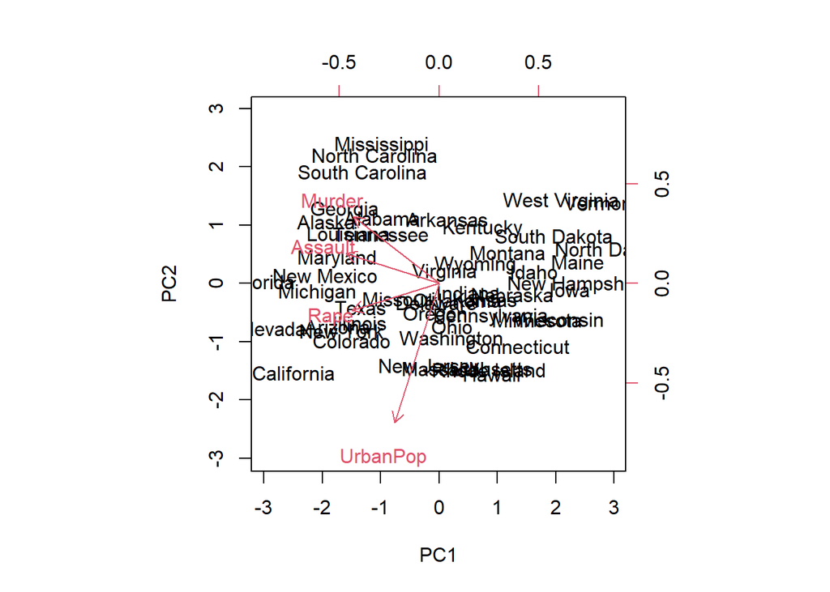

```r
pr.out=prcomp(USArrests, scale=TRUE)
biplot(pr.out, scale=0)
```

**10. Create a scree plot to examine what number of principal components contain a majority of the information in the data set.**

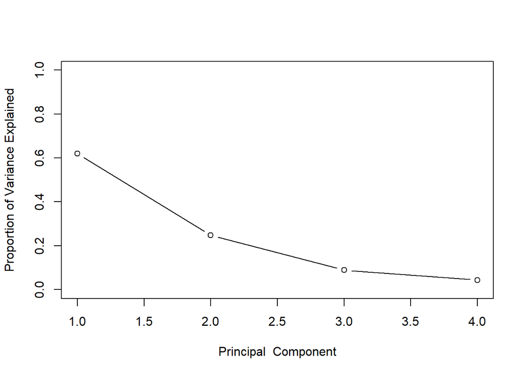

```r
pr.var=pr.out$sdev^2
pve=pr.var/sum(pr.var)

plot(pve, xlab="Principal  Component", ylab="Proportion of Variance Explained", ylim=c(0,1),type="b")
```

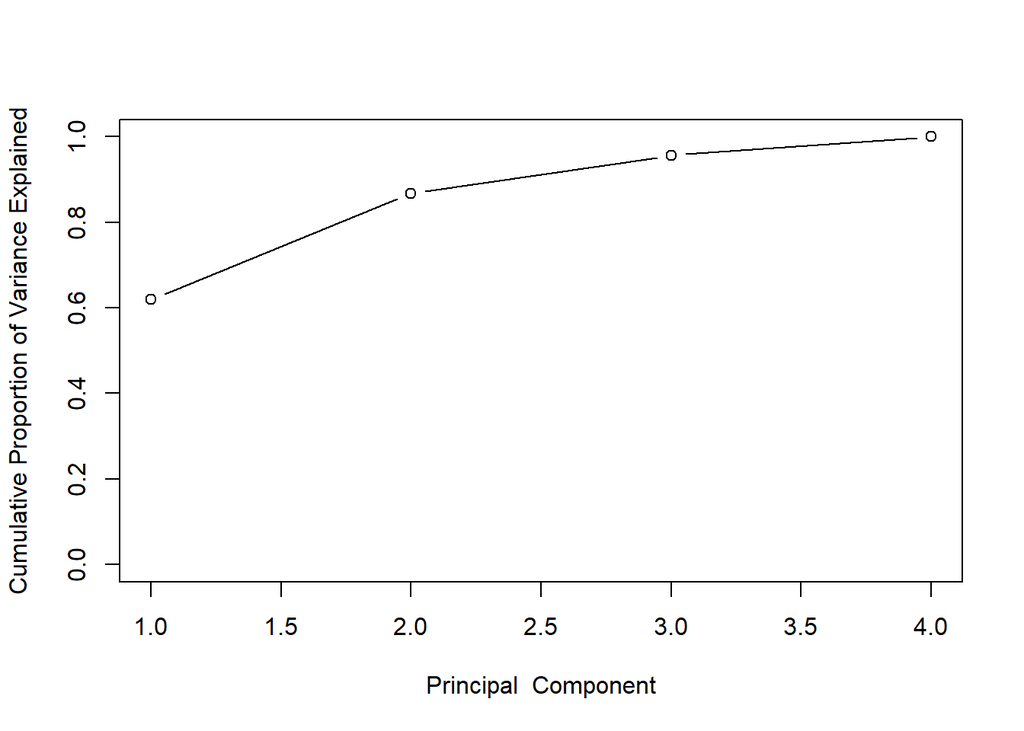

```r
plot(cumsum(pve), xlab="Principal  Component", ylab="Cumulative Proportion of Variance Explained", ylim=c(0,1),type="b")
```

**11. Report the PVE values. Based on these and your plot in (10), choose a number of PCs to use that is less than p. Be sure to explain your choice.**

- Considering the ‘elbow’ in the above graphs around 2-3 PCs and the fact that the first two PCs are able to explain almost 87% of the variability so I think 2 PCs is a good choice.

```r
pve
```

```
## [1] 0.62006039 0.24744129 0.08914080 0.04335752
```

## Hierachical Clustering

**12. Using hierarchical clustering with complete linkage and Euclidean distance, cluster the states. Instead of using the original data, use the number of principal components that you chose in (11).**

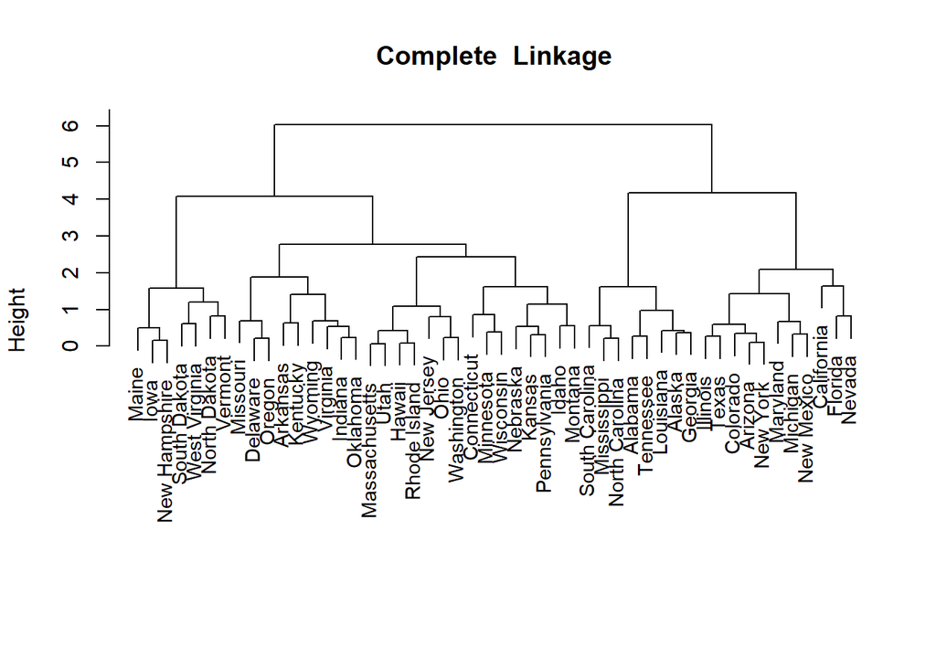

```r
hc.complete = hclust(dist(pr.out$x[,1:2]), method='complete')
plot(hc.complete, main="Complete  Linkage", xlab="", sub="", cex=.9)
```

**13. Cut the dendrogram at a height that results in three distinct clusters. Which states belong to which clusters?**

```r
cutree(hc.complete, 3)
```

```
##        Alabama         Alaska        Arizona       Arkansas     California
##              1              1              2              3              2
##       Colorado    Connecticut       Delaware        Florida        Georgia
##              2              3              3              2              1
##         Hawaii          Idaho       Illinois        Indiana           Iowa
##              3              3              2              3              3
##         Kansas       Kentucky      Louisiana          Maine       Maryland
##              3              3              1              3              2
##  Massachusetts       Michigan      Minnesota    Mississippi       Missouri
##              3              2              3              1              3
##        Montana       Nebraska         Nevada  New Hampshire     New Jersey
##              3              3              2              3              3
##     New Mexico       New York North Carolina   North Dakota           Ohio
##              2              2              1              3              3
##       Oklahoma         Oregon   Pennsylvania   Rhode Island South Carolina
##              3              3              3              3              1
##   South Dakota      Tennessee          Texas           Utah        Vermont
##              3              1              2              3              3
##       Virginia     Washington  West Virginia      Wisconsin        Wyoming
##              3              3              3              3              3
```

## K-Means Clustering

**14. Use K-means to cluster the states with K =3. Be sure to do this with a few different sets of starting values. Choose the best one and compare your ﬁnal clusters to the results of the hierarchical clustering. Again, use the principal components you decided on in (11).**

```r
km.out=kmeans(pr.out$x[,1:2], 3, nstart=20)
km.out$cluster
```

```
##        Alabama         Alaska        Arizona       Arkansas     California
##              1              1              1              2              1
##       Colorado    Connecticut       Delaware        Florida        Georgia
##              1              2              2              1              1
##         Hawaii          Idaho       Illinois        Indiana           Iowa
##              2              3              1              2              3
##         Kansas       Kentucky      Louisiana          Maine       Maryland
##              2              3              1              3              1
##  Massachusetts       Michigan      Minnesota    Mississippi       Missouri
##              2              1              3              1              1
##        Montana       Nebraska         Nevada  New Hampshire     New Jersey
##              3              2              1              3              2
##     New Mexico       New York North Carolina   North Dakota           Ohio
##              1              1              1              3              2
##       Oklahoma         Oregon   Pennsylvania   Rhode Island South Carolina
##              2              2              2              2              1
##   South Dakota      Tennessee          Texas           Utah        Vermont
##              3              1              1              2              3
##       Virginia     Washington  West Virginia      Wisconsin        Wyoming
##              2              2              3              3              2
```

```r
km.out$tot.withinss
```

```
## [1] 53.1051
```

```r
km.out=kmeans(pr.out$x[,1:2], 3, nstart=100)
km.out$cluster
```

```
##        Alabama         Alaska        Arizona       Arkansas     California
##              3              3              3              1              3
##       Colorado    Connecticut       Delaware        Florida        Georgia
##              3              1              1              3              3
##         Hawaii          Idaho       Illinois        Indiana           Iowa
##              1              2              3              1              2
##         Kansas       Kentucky      Louisiana          Maine       Maryland
##              1              2              3              2              3
##  Massachusetts       Michigan      Minnesota    Mississippi       Missouri
##              1              3              2              3              3
##        Montana       Nebraska         Nevada  New Hampshire     New Jersey
##              2              1              3              2              1
##     New Mexico       New York North Carolina   North Dakota           Ohio
##              3              3              3              2              1
##       Oklahoma         Oregon   Pennsylvania   Rhode Island South Carolina
##              1              1              1              1              3
##   South Dakota      Tennessee          Texas           Utah        Vermont
##              2              3              3              1              2
##       Virginia     Washington  West Virginia      Wisconsin        Wyoming
##              1              1              2              2              1
```

```r
km.out$tot.withinss
```

```
## [1] 53.1051
```

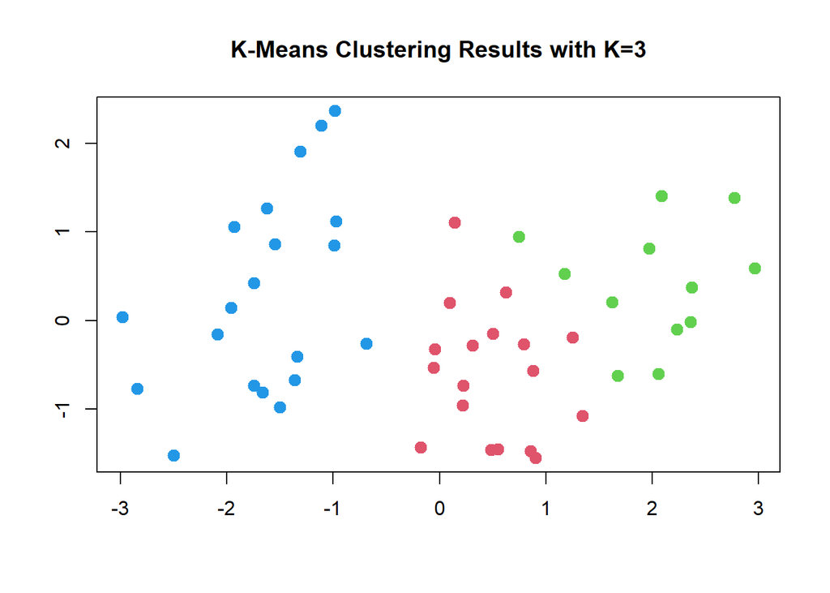

```r
plot(pr.out$x[,1:2], col=(km.out$cluster+1), main="K-Means Clustering Results with K=3", xlab="", ylab="", pch=20, cex=2)
```

```r
table(km.out$cluster,cutree(hc.complete, 3))
```

```
##
##      1  2  3
##   1  0  0 18
##   2  0  0 12
##   3  8 11  1
```

**15. Use K-means to cluster for multiple values of K. Pick the value of K that minimizes the within-cluster variation. Does this produce a value other than 3? How much dfferent are the clustering results than what you compared in (14)? Again, use the principal components you decided on in (11).**

- Using other values of K does not appear to improve the results compared to 14.

```r
km.out=kmeans(pr.out$x[,1:2], 1, nstart=200)
km.out$cluster
```

```
##        Alabama         Alaska        Arizona       Arkansas     California
##              1              1              1              1              1
##       Colorado    Connecticut       Delaware        Florida        Georgia
##              1              1              1              1              1
##         Hawaii          Idaho       Illinois        Indiana           Iowa
##              1              1              1              1              1
##         Kansas       Kentucky      Louisiana          Maine       Maryland
##              1              1              1              1              1
##  Massachusetts       Michigan      Minnesota    Mississippi       Missouri
##              1              1              1              1              1
##        Montana       Nebraska         Nevada  New Hampshire     New Jersey
##              1              1              1              1              1
##     New Mexico       New York North Carolina   North Dakota           Ohio
##              1              1              1              1              1
##       Oklahoma         Oregon   Pennsylvania   Rhode Island South Carolina
##              1              1              1              1              1
##   South Dakota      Tennessee          Texas           Utah        Vermont
##              1              1              1              1              1
##       Virginia     Washington  West Virginia      Wisconsin        Wyoming
##              1              1              1              1              1
```

```r
km.out$tot.withinss
```

```
## [1] 170.0303
```

```r
km.out=kmeans(pr.out$x[,1:2], 2, nstart=200)
km.out$cluster
```

```
##        Alabama         Alaska        Arizona       Arkansas     California
##              1              1              1              2              1
##       Colorado    Connecticut       Delaware        Florida        Georgia
##              1              2              2              1              1
##         Hawaii          Idaho       Illinois        Indiana           Iowa
##              2              2              1              2              2
##         Kansas       Kentucky      Louisiana          Maine       Maryland
##              2              2              1              2              1
##  Massachusetts       Michigan      Minnesota    Mississippi       Missouri
##              2              1              2              1              1
##        Montana       Nebraska         Nevada  New Hampshire     New Jersey
##              2              2              1              2              2
##     New Mexico       New York North Carolina   North Dakota           Ohio
##              1              1              1              2              2
##       Oklahoma         Oregon   Pennsylvania   Rhode Island South Carolina
##              2              2              2              2              1
##   South Dakota      Tennessee          Texas           Utah        Vermont
##              2              1              1              2              2
##       Virginia     Washington  West Virginia      Wisconsin        Wyoming
##              2              2              2              2              2
```

```r
km.out$tot.withinss
```

```
## [1] 76.89308
```

```r
km.out=kmeans(pr.out$x[,1:2], 3, nstart=200)
km.out$cluster
```

```
##        Alabama         Alaska        Arizona       Arkansas     California
##              2              2              2              1              2
##       Colorado    Connecticut       Delaware        Florida        Georgia
##              2              1              1              2              2
##         Hawaii          Idaho       Illinois        Indiana           Iowa
##              1              3              2              1              3
##         Kansas       Kentucky      Louisiana          Maine       Maryland
##              1              3              2              3              2
##  Massachusetts       Michigan      Minnesota    Mississippi       Missouri
##              1              2              3              2              2
##        Montana       Nebraska         Nevada  New Hampshire     New Jersey
##              3              1              2              3              1
##     New Mexico       New York North Carolina   North Dakota           Ohio
##              2              2              2              3              1
##       Oklahoma         Oregon   Pennsylvania   Rhode Island South Carolina
##              1              1              1              1              2
##   South Dakota      Tennessee          Texas           Utah        Vermont
##              3              2              2              1              3
##       Virginia     Washington  West Virginia      Wisconsin        Wyoming
##              1              1              3              3              1
```

```r
km.out$tot.withinss
```

```
## [1] 53.1051
```

# Problem 3.

**16. Split the data set into a training set and a test set.**

```r
attach(College)
train2 = sample(1:nrow(College), .8*nrow(College))
test = -train
```

**17. Fit a linear model using least squares on the training set, and report the test error obtained.**

```r
lmod = lm(Apps~., data=College[train,])
lmod.pred = predict(lmod, College[test,])
mean((lmod.pred-College[test,2])^2)
```

```
## [1] 789172.1
```

## Ridge Regression

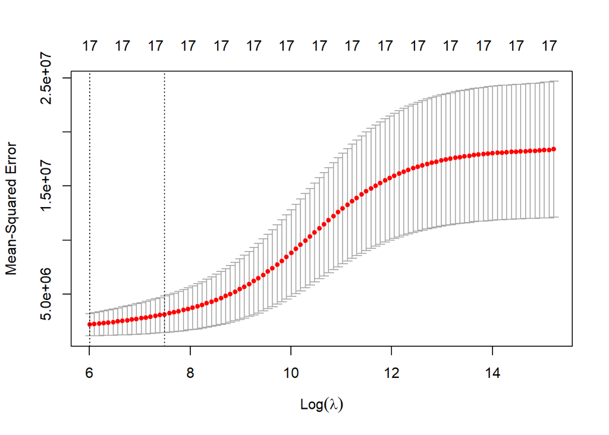

```r
x=model.matrix(Apps~.,College)[,-1]
y=College$Apps

set.seed(1)
train=sample(1:nrow(x), nrow(x)/2)
test=(-train)
y.test=y[test]

cv.out=cv.glmnet(x[train,],y[train],alpha=0)
plot(cv.out)
```

```r
bestlam=cv.out$lambda.min
bestlam
```

```
## [1] 405.8404
```

```r
grid=10^seq(10,-2,length=100)
ridge.mod=glmnet(x[train ,],y[train],alpha=0,lambda=grid,thresh=1e-12)

ridge.pred=predict(ridge.mod,s=bestlam ,newx=x[test,])
mean((ridge.pred-y.test)^2)
```

```
## [1] 976647.8
```

## LASSO

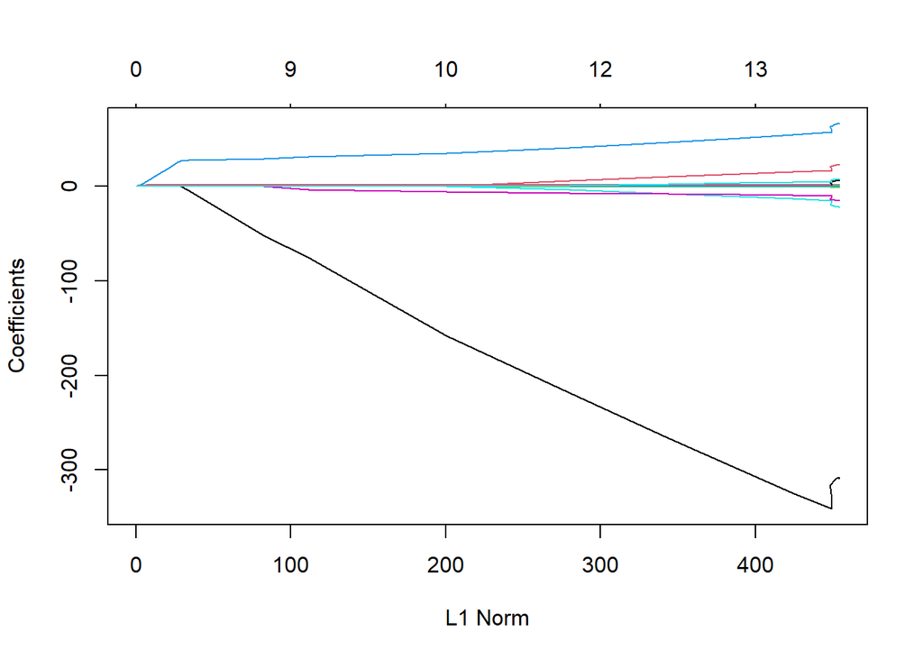

```r
lasso.mod=glmnet(x[train,],y[train],alpha=1,lambda=grid)
plot(lasso.mod)
```

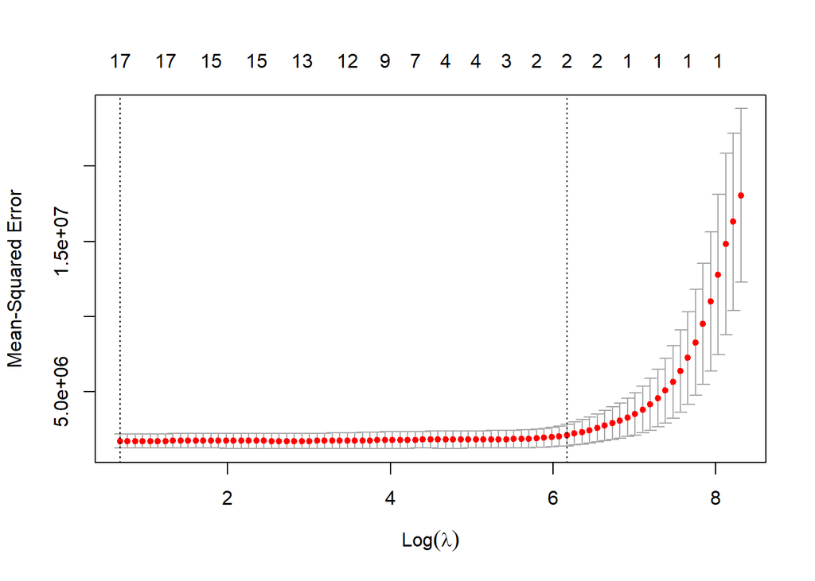

```r
set.seed(1)
cv.out=cv.glmnet(x[train,],y[train],alpha=1)
plot(cv.out)
```

```r
bestlam=cv.out$lambda.min
bestlam
```

```
## [1] 1.97344
```

```r
lasso.pred=predict(lasso.mod,s=bestlam ,newx=x[test,])
mean((lasso.pred-y.test)^2)
```

```
## [1] 1116252
```

## Principal Components Regression

**20. Fit a PCR (Principal Components Regression) model on the training set, with M chosen by cross validation. Report the test error obtained, along with the value of M selected by cross-validation.**

- In the validation plot it appears that using a model with M=5 is essentially the same as any model with M>5 up to about 16.

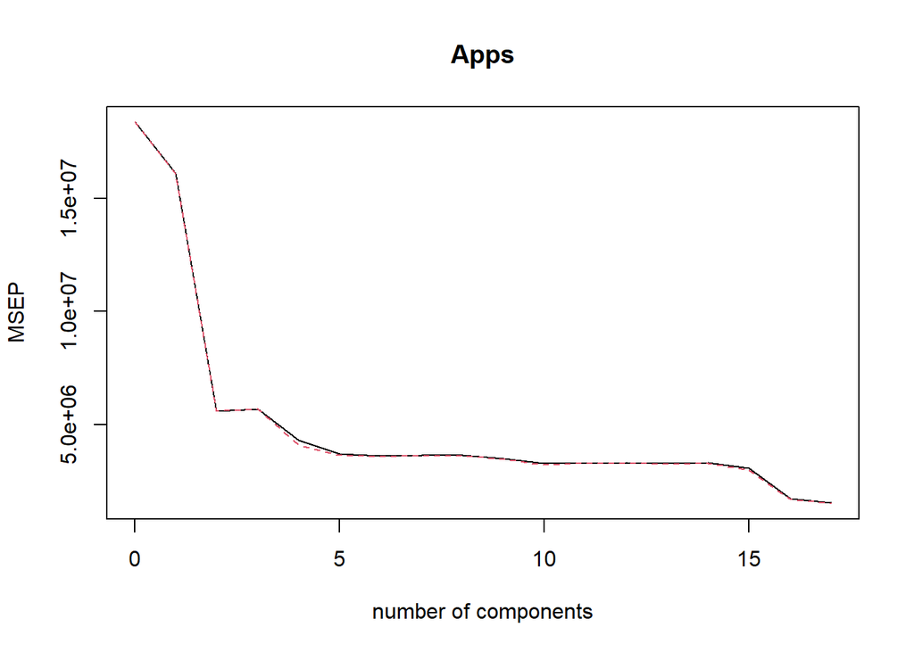

```r
pcr.fit=pcr(Apps~., data=College,subset=train ,scale=TRUE, validation ="CV")
validationplot(pcr.fit,val.type="MSEP")
```

```r
summary(pcr.fit)
```

```
## Data:    X dimension: 388 17
##  Y dimension: 388 1
## Fit method: svdpc
## Number of components considered: 17
##
## VALIDATION: RMSEP
## Cross-validated using 10 random segments.
##        (Intercept)  1 comps  2 comps  3 comps  4 comps  5 comps  6 comps
## CV            4288     4013     2368     2388     2072     1926     1900
## adjCV         4288     4012     2364     2386     2025     1907     1893
##        7 comps  8 comps  9 comps  10 comps  11 comps  12 comps  13 comps
## CV        1905     1907     1868      1811      1815      1820      1809
## adjCV     1899     1903     1862      1799      1807      1812      1801
##        14 comps  15 comps  16 comps  17 comps
## CV         1819      1753      1312      1236
## adjCV      1813      1725      1298      1225
##
## TRAINING: % variance explained
##       1 comps  2 comps  3 comps  4 comps  5 comps  6 comps  7 comps  8 comps
## X       32.20    57.78    65.31    70.99    76.37    81.27     84.8    87.85
## Apps    13.44    70.93    71.07    79.87    81.15    82.25     82.3    82.33
##       9 comps  10 comps  11 comps  12 comps  13 comps  14 comps  15 comps
## X       90.62     92.91     94.98     96.74     97.79     98.72     99.42
## Apps    83.38     84.76     84.80     84.84     85.11     85.14     90.55
##       16 comps  17 comps
## X        99.88    100.00
## Apps     93.42     93.89
```

```r
pcr.pred=predict(pcr.fit,x[test,],ncomp=16)
mean((pcr.pred-y.test)^2)
```

```
## [1] 1137877
```

```r
pcr.pred=predict(pcr.fit,x[test,],ncomp=5)
mean((pcr.pred-y.test)^2)
```

```
## [1] 1983650
```

**21. Comment on the results obtained. How accurately can we predict the number of college applications received? Is there much difference among the test errors resulting from these four approaches?**

- It appears that it is quite difficult to accurately predict the number of college applications, However there is not a terrible amount of difference between the test errors across different models provided they use most of the data available.